# Changes to video game play during the COVID-19 pandemic

Matti Vuorre https://vuorre.netlify.com (University of Oxford)https://www.oii.ox.ac.uk/people/matti-vuorre/  
2021-02-10

## Preface

We study changes in gaming behavior during COVID-19 using data from the [Steam](https://store.steampowered.com/) gaming platform. The data were scraped from [Steam Database](https://steamdb.info/) in January 2021.

The data, code, and analysis documents are available at

- OSF: https://osf.io/ya9jt/ (long term repository for code and output)
- GitHub repository: https://github.com/digital-wellbeing/steam-lockdown (most up to date code)
- Online supplement: https://digital-wellbeing.github.io/steam-lockdown (most up to date analysis output)

The rest of this document describes the dataset, and how we cleaned and analysed it. We used the following R packages:

```r
library(readxl)
library(knitr)
library(broom)
library(COVID19)
library(lubridate)
library(scales)
library(emmeans)
library(mgcv)
library(patchwork)
library(tidyverse)
```

## Data processing

The data are in individual files for each of 500 titles time-series, and a separate file for the manual coding (e.g. whether a title was multiplayer or not). We loaded the time series data files into one R object, and then joined the timeseries with the manually coded table of features

```r
# From files in this directory
paths <- list.files("data-raw/Top 500 Games Jan 2021/", full.names = TRUE)
# Read these columns in these formats
COLS <- cols_only(
  DateTime = "T",
  Players = "d"
)
dat <- tibble(appid = paths) %>%
  mutate(data = map(appid, ~read_csv(., col_types = COLS))) %>%
  mutate(appid = str_remove(basename(paths), ".csv")) %>%
  unnest(data) %>%
  # There is no time info in DateTime
  rename(Date = DateTime) %>%
  mutate(Date = as.Date(Date))
# Limit to 2019 and 2020
dat <- dat %>%
  filter(Date >= as.Date("2019-01-01"), Date <= as.Date("2020-12-31"))

# Join player counts with metadata (coding)
titles <- read_excel(
  "data-raw/500 Steam Games Coding FINAL.xlsx",
  col_types = "text"
)
# Variable names and values (labels) needed some cleaning
names(titles) <- c("appid", "name", "LB", "MP", "COOP")
titles$LB <- ifelse(titles$LB == "N0", "NN", titles$LB)
titles$LB <- ifelse(titles$LB == "Y0", "YY", titles$LB)
titles <- titles %>%
  mutate(across(LB:COOP, ~factor(ifelse(.=="NN", "No", "Yes"))))
# We focused on multiplayer vs single player
titles <- select(titles, appid, name, MP)
titles <- mutate(
  titles,
  MP = factor(
    MP,
    levels = c("Yes", "No"),
    labels = c("Multiplayer", "Single player")
  )
)
# Join tables
dat <- left_join(titles, dat)

# Summarise to a sum per day
dat <- dat %>%
  group_by(Date, MP) %>%
  summarise(Players = sum(Players, na.rm = TRUE)) %>%
  ungroup() %>%
  mutate(Players = Players / 1e6)

# Add useful time indicators
dat <- dat %>%
  mutate(
    year = factor(year(Date)),
    yweek = week(Date)-1,  # Week number
    yday = yday(Date)-1,  # Day number
    # Weekday number starting from Monday
    wday = wday(Date, week_start = 1, label = FALSE)-1
  )

# COVID data for top 10 Steam countries
dat_covid <- covid19(c("USA", "Russia", "Brazil", "Germany", "Canada", "France", "United Kingdom", "Poland", "Turkey"))
# unique(dat_covid$id)
dat_covid <- dat_covid %>%
  mutate(
    Country = factor(
      id, levels = c("USA", "RUS", "BRA", "DEU", "CAN", "FRA", "GBR", "POL", "TUR"),
      labels = c("United States", "Russia", "Brazil", "Germany", "Canada", "France", "United Kingdom", "Poland", "Turkey"))
    )
```

## Data description

The data were collapsed to a sum count per category (multiplayer [345 titles] vs single player [155 titles]) for each day. (The Players variable was rescaled to indicate millions; this sometimes prevents problems with model convergence.)

```r
kable(head(dat), caption = "First six rows of data", digits = 2)
```

Table 1: First six rows of data

| Date | MP | Players | year | yweek | yday | wday |
| --- | --- | --- | --- | --- | --- | --- |
| 2019-01-01 | Multiplayer | 4.17 | 2019 | 0 | 0 | 1 |
| 2019-01-01 | Single player | 0.44 | 2019 | 0 | 0 | 1 |
| 2019-01-02 | Multiplayer | 4.13 | 2019 | 0 | 1 | 2 |
| 2019-01-02 | Single player | 0.40 | 2019 | 0 | 1 | 2 |
| 2019-01-03 | Multiplayer | 4.07 | 2019 | 0 | 2 | 3 |
| 2019-01-03 | Single player | 0.39 | 2019 | 0 | 2 | 3 |

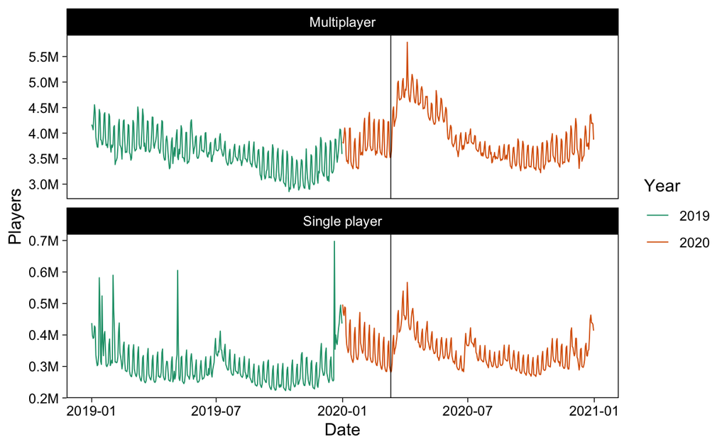

Figure 1: Daily players in 2019 and 2020. Vertical line indicates the March 11th, 2020, WHO announcement of a global pandemic.

```r
# Date of WHO announcement
cd <- as.Date("2020-03-11")
# Function to format Y axis neatly
label_fun <- function(x, n=1) str_glue("{format(round(x, n), nsmall=n)}M")
# Use these colors throughout
colorpal <- function(x)
  scale_color_brewer(
    "Year", palette = "Dark2",
    aesthetics = c("color", "fill")
  )
dat %>%
  ggplot(aes(Date, Players, col = year)) +
  colorpal() +
  geom_line(size = 1/3) +
  geom_vline(xintercept = cd, size = 1/4) +
  scale_y_continuous(
    breaks = pretty_breaks(),
    labels = label_fun
  ) +
  facet_wrap("MP", nrow = 2, scales = "free_y")
```

## Modelling

We modelled the daily multi- and singleplayer players from 2019 Jan 1st to end of 2020. We fit a generalized additive model of the daily player count on smooth functions of week number and weekday, and their interaction, using tensor product interactions as implemented in the R package mgcv. We also modelled different variances by year and game type because heteroskedasticity was plausible (in fact there must be vast differences between single and multiplayer). The model included separate smooths for each of the four “cells” (year: 2019 and 2020; type: multi- and single player) to allow comparisons between years and game types.

```r
# We will use grouping factor G that includes the four year by game type "conditions". This allows us to do separate smooths for each cell and thus all comparisons we are interested in within the one model.
dat <- dat %>%
  mutate(M = ifelse(MP=="Multiplayer", "MP", "SP")) %>%
  mutate(G = interaction(year, M))
if (!file.exists("models/mgcv.rda")) {
  fit1 <- gam(
    list(
      Players ~ G + ti(yweek, k = 52, by = G) +
        ti(wday, k = 7, by = G) +
        ti(yweek, wday, k = c(26, 7), by = G),
      ~ G
    ),
    family = gaulss(), method = "REML",
    data = dat
  )
  fit2 <- gam(
    list(
      Players ~ G + ti(yweek, k = 52, by = G) +
        ti(wday, k = 7, by = G) +
        ti(yweek, wday, k = c(26, 7), by = G),
      ~ G + s(yweek, k = 6, by = G)
    ),
    family = gaulss(), method = "REML",
    data = dat
  )
  save(fit1, fit2, file = "models/mgcv.rda", compress = FALSE)
} else {load("models/mgcv.rda")}
```

### Summary

The model summaries themselves are somewhat difficult to interpret and not necessarily of direct interest, but are printed below. Possibly of interest are the `ti()` terms that indicate how wiggly the changes in the number of players were over time (`ti(yweek)`) over a week (`ti(wday)`), and how wiggly the interaction between those was (`ti(yweek, wday)`; i.e. the weekday by week interaction effect). `G2019.MP` = the effect for 2019 multiplayer. This “wiggliness” is reflected in the `edf` (estimated degrees of freedom) value, that indicates roughly how many parameters (we used penalized smooths) were needed to describe the smooth. Greater numbers indicate greater wiggliness.

```r
kable(
  tidy(fit1, parametric = FALSE), digits = c(0,1,1,2,3),
  caption = "Smooth terms of generalized additive model."
)
```

Table 2: Smooth terms of generalized additive model.

| term | edf | ref.df | statistic | p.value |
| --- | --- | --- | --- | --- |
| ti(yweek):G2019.MP | 34.8 | 41.1 | 5106.79 | 0.000 |
| ti(yweek):G2020.MP | 39.2 | 45.0 | 11884.33 | 0.000 |
| ti(yweek):G2019.SP | 16.0 | 19.9 | 483.74 | 0.000 |
| ti(yweek):G2020.SP | 42.0 | 47.1 | 5603.50 | 0.000 |
| ti(wday):G2019.MP | 5.9 | 6.0 | 3376.65 | 0.000 |
| ti(wday):G2020.MP | 5.8 | 6.0 | 2263.00 | 0.000 |
| ti(wday):G2019.SP | 4.4 | 5.2 | 259.28 | 0.000 |
| ti(wday):G2020.SP | 5.8 | 6.0 | 2122.09 | 0.000 |
| ti(yweek,wday):G2019.MP | 27.7 | 38.8 | 215.07 | 0.000 |
| ti(yweek,wday):G2020.MP | 36.9 | 51.7 | 294.08 | 0.000 |
| ti(yweek,wday):G2019.SP | 8.3 | 12.1 | 21.61 | 0.044 |
| ti(yweek,wday):G2020.SP | 29.8 | 42.7 | 217.23 | 0.000 |

### Player figure

We then drew fitted lines and uncertainty intervals of the timeseries, and differences between years 2020 and 2019 over time. This allowed us to visualise the observed differences between years (hypothesized “excess play” in 2020), and model-implied uncertainties of those differences.

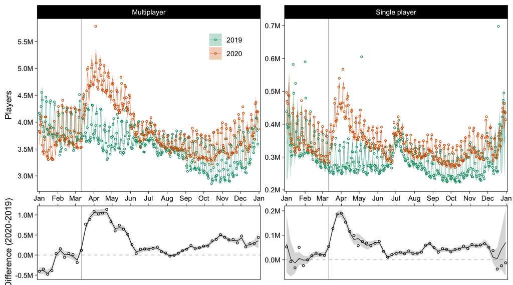

```r
# Create table of data and predictions
predictions <- predict(fit2, se.fit = TRUE) %>%
  as.data.frame() %>%
  as_tibble()
predictions <- bind_cols(dat, predictions)

# Draw figure of data and predictions
p_players <- predictions %>%
  # Dates from 2020 for plotting
  group_by(yday) %>%
  mutate(Date = last(Date)) %>%
  ggplot(aes(Date, Players, col = year, group = year, fill = year)) +
  colorpal() +
  geom_vline(xintercept = cd, size = .1) +
  scale_y_continuous(
    breaks = pretty_breaks(), labels = label_fun
  ) +
  scale_x_date(
    expand = expansion(0.01), date_breaks = "1 month", date_labels = "%b"
  ) +
  geom_ribbon(
    aes(ymin = fit.1-se.fit.1*1.96, ymax = fit.1+se.fit.1*1.96),
    alpha = .3, col = NA
  ) +
  geom_point(shape = 1, size = 0.85) +
  geom_line(aes(y = fit.1), size = .15, alpha = .9) +
  facet_wrap("MP", scales = "free", nrow = 1) +
  theme(
    axis.title.x = element_blank(),
    legend.title = element_blank(),
    plot.margin = unit(c(1, 1, 1, 1), "pt"),
    legend.position = c(.4, .85)
  )

# "Excess play" figure
# Observed difference between years from data
tmp <- predictions %>%
  select(MP, year, yweek, Players) %>%
  pivot_wider(names_from = year, values_from = Players, values_fn = mean) %>%
  mutate(Difference = `2020`-`2019`)

# Model-implied differences between years using emmeans
# the documentation for average contrasts in ?emmeans is confusing (and possibly wrong for GAMs), so we must ensure here that results are averaged over weekdays, so that we get predictions (and differences) of weekly averages and not e.g. wednesdays
emm <- emmeans(
  fit2, "G", by = "yweek", at = list(yweek = 0:52),
  cov.reduce = FALSE
)
# emm  # Ensure that message says averaged over wday
# Get pairwise comparisons between cells at each week
emmp <- pairs(emm, reverse = TRUE) %>%
  as.data.frame() %>%
  as_tibble()
# Contrast years within MP/SP
emmp <- emmp %>%
  filter(contrast %in% c("2020.MP - 2019.MP", "2020.SP - 2019.SP")) %>%
  mutate(
    MP = ifelse(str_detect(contrast, "MP"), "Multiplayer", "Single player")
  )

# Draw figure of observed differences and model contrasts
p_excess <- tmp %>%
  left_join(emmp) %>%
  mutate(year = "Difference (2020 - 2019)") %>%
  # Convert week number to approx 2020 date for plotting
  mutate(Date = ymd("2020-01-01") + weeks(yweek)) %>%
  ggplot(aes(Date, estimate)) +
  geom_vline(xintercept = cd, size = .1) +
  scale_y_continuous(
    "Difference (2020-2019)",
    labels = label_fun
  ) +
  scale_x_date(
    expand = expansion(0.01), date_breaks = "1 month",
    date_labels = "%b", position = "top"
  ) +
  geom_hline(yintercept = 0, size = .1, lty = 2) +
  geom_point(aes(y=Difference), shape = 1, size = 1) +
  geom_ribbon(
    aes(ymin = (estimate-SE*2), ymax = (estimate+SE*2)),
    alpha = .2
  ) +
  geom_line(size = .3) +
  facet_wrap("MP", scales = "free") +
  theme(
    axis.title.x = element_blank(),
    axis.text.x = element_blank(),
    strip.background.x = element_blank(),
    plot.margin = unit(c(1, 1, 1, 1), "pt"),
    strip.text.x = element_blank()
  )

# Change the layout of the panels a bit
(p_players / p_excess) + plot_layout(heights = c(7, 3))
```

Numeric display of excess players in 2020 April

```r
dat %>%
  mutate(month = month(Date, label = TRUE)) %>%
  filter(month == "Apr") %>%
  select(year, month, yweek, MP, Players) %>%
  pivot_wider(names_from = year, values_from = Players, values_fn = mean) %>%
  mutate(Difference = `2020`-`2019`) %>%
  group_by(MP) %>%
  filter(Difference == max(Difference, na.rm = TRUE)) %>%
  kable(
    caption = "Peak weekly player counts (and difference) in April",
    digits = 2
  )
```

Table 3: Peak weekly player counts (and difference) in April

| month | yweek | MP | 2019 | 2020 | Difference |
| --- | --- | --- | --- | --- | --- |
| Apr | 13 | Single player | 0.28 | 0.47 | 0.19 |
| Apr | 16 | Multiplayer | 3.54 | 4.68 | 1.14 |

### Game type figure

Figure of differences between multi- and single player games in 2019 and 2020.

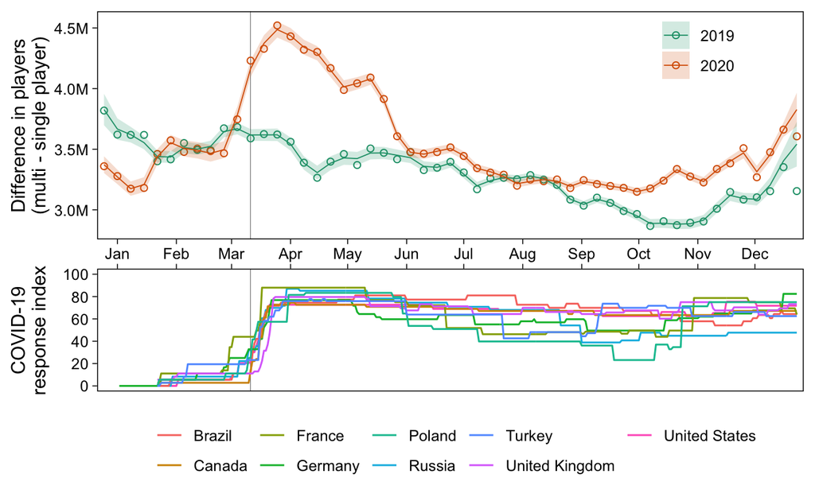

Figure 3: Weekly difference between multiplayer and single player games.

```r
tmp <- dat %>%
  group_by(year, yweek, MP) %>%
  summarise(Players = mean(Players)) %>%
  pivot_wider(names_from = MP, values_from = Players) %>%
  mutate(d = Multiplayer - `Single player`)
# Difference in multi vs single player
emm <- emmeans(
  fit2, "G", by = "yweek", at = list(yweek = 0:52),
  cov.reduce = FALSE
)
emmc <- contrast(
  emm,
  method = list(`2019` = c(1, 0, -1, 0), `2020` = c(0, 1, 0, -1))
) %>%
  as.data.frame() %>%
  as_tibble() %>%
  rename(year = contrast) %>%
  left_join(tmp) %>%
  # Convert week number to approx 2020 date for plotting
  mutate(Date = ymd("2020-01-01") + weeks(yweek-1))

p_gametype <- emmc %>%
  ggplot(aes(Date, d, col = year, group = year, fill = year)) +
  colorpal() +
  scale_x_date(
    expand = expansion(0.01), date_breaks = "1 month", date_labels = "%b"
  ) +
  geom_vline(xintercept = cd, size = .1) +
  geom_point(shape = 1) +
  geom_ribbon(
    aes(ymin = (estimate-SE*2), ymax = (estimate+SE*2)),
    alpha = .2, col = NA
  ) +
  geom_line(aes(y = estimate), size = .3) +
  geom_vline(xintercept = floor(yday(cd) / 7), size = 1/4) +
  scale_y_continuous(
    "Difference in players\n(multi - single player)",
    breaks = pretty_breaks(),
    labels = label_fun
  ) +
  theme(
    axis.title.x = element_blank(),
    legend.title = element_blank(),
    legend.background = element_blank(),
    legend.position = c(.85, .85),
    plot.margin = unit(c(1, 1, 1, 1), "pt")
  )

# Figure of COVID trends
p_covid <- dat_covid %>%
  filter(year(date)==2020, date <= max(emmc$Date)) %>%
  ggplot(aes(date, stringency_index, color = Country)) +
  # scale_color_discrete() +
  # Make sure the time span is same as above
  geom_blank(data = emmc, aes(Date, estimate, color = NA)) +
  scale_y_continuous(
    "COVID-19\nresponse index", breaks = pretty_breaks(),
    limits = c(0, 100)
  ) +
  geom_vline(xintercept = cd, size = .1) +
  scale_x_date(
    expand = expansion(0.01), date_breaks = "1 month",
    date_labels = "%b", position = "top"
  ) +
  geom_line() +
  theme(
    axis.title.x = element_blank(),
    axis.text.x = element_blank(),
    legend.title = element_blank(),
    legend.position = "bottom",
    plot.margin = unit(c(0, 1, 1, 1), "pt")
  )

(p_gametype / p_covid) + plot_layout(heights = c(6.5, 3.5))
```

Numeric display of differences between multi- and single player counts

```r
# Difference in February and max difference in 2020 and 2019
dat %>%
  mutate(month = month(Date, label = TRUE)) %>%
  filter(month %in% c("Feb", "Apr")) %>%
  select(year, month, MP, Players) %>%
  pivot_wider(names_from = MP, values_from = Players, values_fn = mean) %>%
  mutate(Difference = Multiplayer-`Single player`) %>%
  kable(
    caption = "Multi- and single player counts and difference at select time points.",
    digits = 2
  )
```

Table 4: Multi- and single player counts and difference at select time points.

| year | month | Multiplayer | Single player | Difference |
| --- | --- | --- | --- | --- |
| 2019 | Feb | 3.79 | 0.34 | 3.45 |
| 2019 | Apr | 3.74 | 0.28 | 3.46 |
| 2020 | Feb | 3.87 | 0.35 | 3.52 |
| 2020 | Apr | 4.80 | 0.42 | 4.38 |

### Weekend figure

We then focused on the weekend effect. How did weekdays differ from one another, and how did that difference change over time? From this we can observe that in 2020, the weekend effect was smaller after roughly week 10 than it was in 2019.

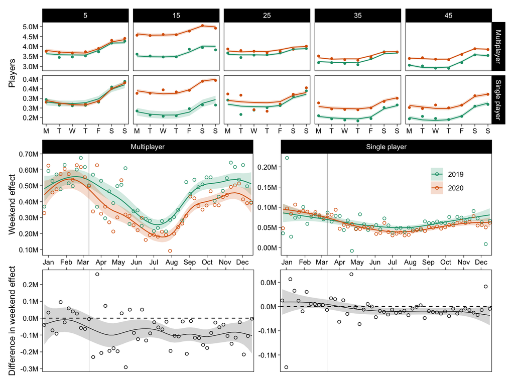

```r
# Create table of data and predictions
predictions <- predict(fit2, se.fit = TRUE) %>%
  as.data.frame() %>%
  as_tibble()
predictions <- bind_cols(dat, predictions)

# Draw observed and model-implied player count for select weeks
p_wend_1 <- left_join(dat, predictions) %>%
  filter(yweek %in% seq(5, 45, by = 10)) %>%
  ggplot(aes(wday, Players, col = year, group = year, fill = year)) +
  colorpal() +
  scale_y_continuous(
    breaks = pretty_breaks(), labels = function(x) label_fun(x, 1)
  ) +
  scale_x_continuous(
    "Day of week", breaks = 0:6,
    labels = c("M", "T", "W", "T", "F", "S", "S")
  ) +
  geom_point(size = 1, shape = 21) +
  geom_ribbon(
    aes(ymin = fit.1 - se.fit.1*1.96, ymax = fit.1 + se.fit.1*1.96),
    alpha = .2, col = NA
  ) +
  geom_line(aes(y = fit.1)) +
  facet_grid(MP~yweek, scales = "free") +
  theme(
    legend.position = "none",
    axis.title.x = element_blank()
  )

# Observed weekday/end player count and difference from data
tmp <- dat %>%
  group_by(year, yweek, MP) %>%
  summarise(
    wday_m = mean(Players[wday %in% 0:4]),
    wend_m = mean(Players[wday %in% 5:6]),
    w_eff = wend_m - wday_m
  ) %>%
  ungroup() %>%
  drop_na(w_eff)  # Doesn't exist for week 53

# Model-implied weekday player numbers
# Note there is no weekend effect for the last week in data
emm <- emmeans(
  fit2, "wday", by = c("G", "yweek"),
  at = list(wday = 0:6, yweek = 0:52)
)
# Calculate model-implied average differences between weekdays and ends
emmz <- contrast(
  emm, infer = TRUE,
  method = list(c(0,0,0,0,0,1,1)/2 - c(1,1,1,1,1,0,0)/5)
) %>%
  as_tibble() %>%
  separate(G, c("year", "MP")) %>%
  mutate(
    MP = ifelse(str_detect(MP, "MP"), "Multiplayer", "Single player")
  )

# Draw observed and model-implied difference between weekend and weekday
p_wend_2 <- left_join(tmp, emmz) %>%
    # Convert week number to approx 2020 date for plotting
  mutate(Date = ymd("2020-01-01") + weeks(yweek-1)) %>%
  ggplot(aes(Date, estimate, col = year, group = year, fill = year)) +
  scale_color_brewer(
    "Year", palette = "Dark2",
    aesthetics = c("color", "fill")
  ) +
  scale_y_continuous(
    "Weekend effect",
    breaks = pretty_breaks(), labels = function(x) label_fun(x, 2)
  ) +
  scale_x_date(
    expand = expansion(0.01), date_breaks = "1 month", date_labels = "%b"
  ) +
  geom_vline(xintercept = cd, size = .1) +
  geom_ribbon(
    aes(ymin = lower.CL, ymax = upper.CL),
    alpha = .2, col = NA
  ) +
  geom_line() +
  geom_point(aes(y = w_eff), shape = 1) +
  facet_wrap("MP", nrow = 1, strip.position = "top", scales = "free") +
  theme(
    legend.position = c(.9, .75),
    legend.title = element_blank(),
    axis.title.x = element_blank(),
    plot.margin = unit(c(1, 1, 1, 1), "pt")
    )

# Difference in weekend effect 2019-2020
emm2 <- emmeans(
  fit2, c("wday", "G"), by = "yweek",
  at = list(wday = 0:6, G = unique(dat$G), yweek = 0:52)
  )

# This beast calculates the difference in weekend effect 2020-2019 for MP and SP
emm2z <- contrast(
  emm2, infer = TRUE,
  method = list(
    MP = c(
      c(0,0,0,0,0,0,0,0,0,0,0,0,1,1, rep(0,14))/2 -
        c(0,0,0,0,0,0,0,1,1,1,1,1,0,0, rep(0, 14))/5
    ) - c(
      c(0,0,0,0,0,1,1,0,0,0,0,0,0,0, rep(0,14))/2 -
      c(1,1,1,1,1,0,0,0,0,0,0,0,0,0, rep(0, 14))/5
    ),
    SP = c(
      c(rep(0,14), 0,0,0,0,0,0,0,0,0,0,0,0,1,1)/2 -
        c(rep(0,14), 0,0,0,0,0,0,0,1,1,1,1,1,0,0)/5
    ) - c(
      c(rep(0,14), 0,0,0,0,0,1,1,0,0,0,0,0,0,0)/2 -
      c(rep(0,14), 1,1,1,1,1,0,0,0,0,0,0,0,0,0)/5
    )
  )
)
emm2z <- as.data.frame(emm2z) %>%
  as_tibble() %>%
  mutate(
    MP = ifelse(str_detect(contrast, "MP"), "Multiplayer", "Single player")
  )
p_wend_3 <- select(tmp, year, yweek, MP, w_eff) %>%
  pivot_wider(names_from = year, values_from = w_eff) %>%
  mutate(Difference = `2020`-`2019`) %>%
  left_join(emm2z) %>%
  # Convert week number to approx 2020 date for plotting
  mutate(Date = ymd("2020-01-01") + weeks(yweek-1)) %>%
  ggplot(aes(Date, Difference)) +
  colorpal() +
  scale_x_date(
    expand = expansion(0.01), date_breaks = "1 month",
    date_labels = "%b", position = "top"
  ) +
  geom_vline(xintercept = cd, size = .1) +
  geom_hline(yintercept = 0, lty = 2) +
  geom_point(shape = 1) +
  geom_ribbon(
    aes(ymin = lower.CL, ymax = upper.CL),
    alpha = .2, col = NA
  ) +
  geom_line(aes(y = estimate), size = .3) +
  scale_y_continuous(
    "Difference in weekend effect",
    breaks = pretty_breaks(),
    labels = label_fun
  ) +
  theme(
    axis.title.x = element_blank(),
    axis.text.x = element_blank(),
    strip.background = element_blank(),
    plot.margin = unit(c(1, 1, 1, 1), "pt"),
    strip.text = element_blank()
  ) +
  facet_wrap("MP", nrow = 1, scales = "free")

# Put the plots together
(p_wend_1 / p_wend_2 / p_wend_3) +
  plot_layout(heights = c(1/3, 1/3, 1/3))
```

Numeric display of weekend effect

```r
dat %>%
  mutate(month = month(Date, label = TRUE)) %>%
  filter(month %in% c("Feb", "Apr")) %>%
  group_by(year, month, yweek, MP) %>%
  summarise(
    wday_m = mean(Players[wday %in% 1:5]),
    wend_m = mean(Players[wday %in% 6:7]),
    w_eff = wend_m - wday_m
  ) %>%
  ungroup() %>%
  drop_na(w_eff) %>%
  group_by(year, month, MP) %>%
  summarise(across(wday_m:w_eff, mean)) %>%
  kable(
    caption = "Weekday effect",
    digits = 2
  )
```

Table 5: Weekday effect

| year | month | MP | wday_m | wend_m | w_eff |
| --- | --- | --- | --- | --- | --- |
| 2019 | Feb | Multiplayer | 3.80 | 4.21 | 0.41 |
| 2019 | Feb | Single player | 0.37 | 0.40 | 0.03 |
| 2019 | Apr | Multiplayer | 3.71 | 4.03 | 0.32 |
| 2019 | Apr | Single player | 0.28 | 0.34 | 0.06 |
| 2020 | Feb | Multiplayer | 3.83 | 4.31 | 0.48 |
| 2020 | Feb | Single player | 0.34 | 0.42 | 0.08 |
| 2020 | Apr | Multiplayer | 4.81 | 4.98 | 0.17 |
| 2020 | Apr | Single player | 0.42 | 0.46 | 0.05 |

### Additional numbers

```r
dat %>%
  mutate(month = month(Date, label = TRUE)) %>%
  filter(month %in% c("Mar", "Apr", "May", "Jun")) %>%
  group_by(year, MP, month) %>%
  summarise(Players = mean(Players)) %>%
  summarise(min = min(Players), max = max(Players)) %>%
  kable(digits = 2, caption = "Ranges of players")
```

Table 6: Ranges of players

| year | MP | min | max |
| --- | --- | --- | --- |
| 2019 | Multiplayer | 3.70 | 3.94 |
| 2019 | Single player | 0.28 | 0.30 |
| 2020 | Multiplayer | 3.85 | 4.80 |
| 2020 | Single player | 0.33 | 0.42 |

```r
dat %>%
  mutate(month = month(Date, label = TRUE)) %>%
  filter(month %in% c("Apr")) %>%
  group_by(year, MP, month) %>%
  summarise(max_Players = max(Players)) %>%
  kable(digits = 2, caption = "Peak players")
```

Table 6: Peak players

| year | MP | month | max_Players |
| --- | --- | --- | --- |
| 2019 | Multiplayer | Apr | 4.24 |
| 2019 | Single player | Apr | 0.36 |
| 2020 | Multiplayer | Apr | 5.78 |
| 2020 | Single player | Apr | 0.57 |

```r
dat %>%
  mutate(month = month(Date, label = TRUE)) %>%
  filter(month %in% c("Feb", "Apr")) %>%
  group_by(year, MP, month) %>%
  summarise(Players = mean(Players)) %>%
  summarise(min = min(Players), max = max(Players)) %>%
  kable(digits = 2, caption = "Ranges of players")
```

Table 6: Ranges of players

| year | MP | min | max |
| --- | --- | --- | --- |
| 2019 | Multiplayer | 3.74 | 3.79 |
| 2019 | Single player | 0.28 | 0.34 |
| 2020 | Multiplayer | 3.87 | 4.80 |
| 2020 | Single player | 0.35 | 0.42 |

## Additional model checking

Just checking. Apart from outliers (look at 2019 single player, quite noisy!) doing pretty well.

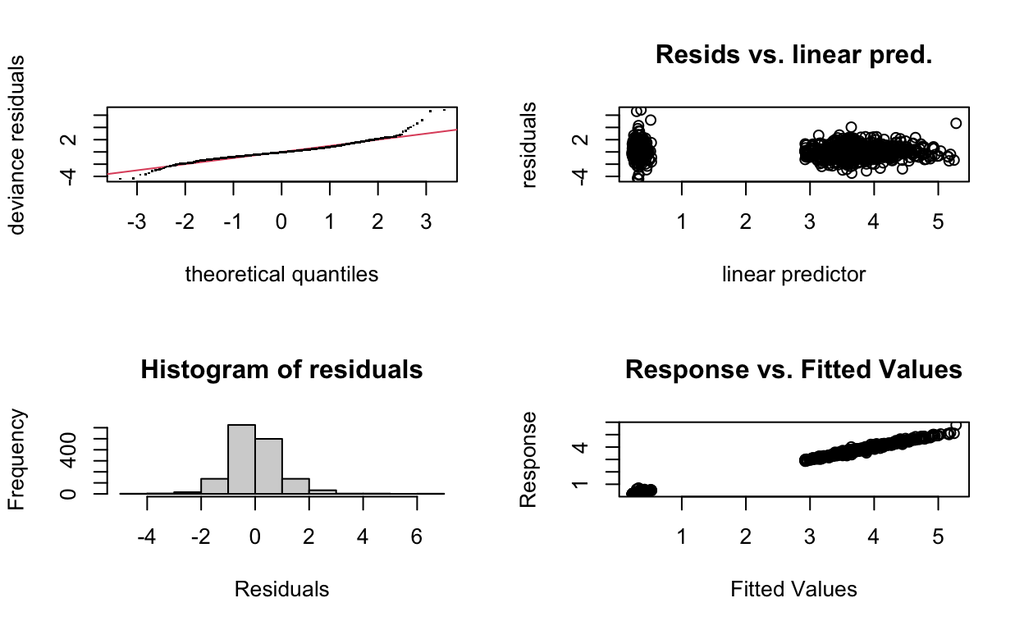

```
Method: REML   Optimizer: outer newton
full convergence after 9 iterations.
Gradient range [-1.426917e-06,1.69075e-05]
(score -2349.344 & scale 1).
Hessian positive definite, eigenvalue range [0.4937978,17.89726].
Model rank =  856 / 856

Basis dimension (k) checking results. Low p-value (k-index<1) may
indicate that k is too low, especially if edf is close to k'.

                            k'    edf k-index p-value
ti(yweek):G2019.MP       51.00  33.94    0.74  <2e-16 ***
ti(yweek):G2020.MP       51.00  39.16    0.74  <2e-16 ***
ti(yweek):G2019.SP       51.00  27.86    0.74  <2e-16 ***
ti(yweek):G2020.SP       51.00  42.18    0.74  <2e-16 ***
ti(wday):G2019.MP         6.00   5.88    0.80  <2e-16 ***
ti(wday):G2020.MP         6.00   5.83    0.80  <2e-16 ***
ti(wday):G2019.SP         6.00   5.70    0.80  <2e-16 ***
ti(wday):G2020.SP         6.00   5.83    0.80  <2e-16 ***
ti(yweek,wday):G2019.MP 150.00  30.48    0.81  <2e-16 ***
ti(yweek,wday):G2020.MP 150.00  36.24    0.81  <2e-16 ***
ti(yweek,wday):G2019.SP 150.00  10.10    0.81  <2e-16 ***
ti(yweek,wday):G2020.SP 150.00  20.33    0.81  <2e-16 ***
s.1(yweek):G2019.MP       5.00   4.46    0.74  <2e-16 ***
s.1(yweek):G2020.MP       5.00   4.21    0.74  <2e-16 ***
s.1(yweek):G2019.SP       5.00   4.87    0.74  <2e-16 ***
s.1(yweek):G2020.SP       5.00   2.61    0.74  <2e-16 ***
---
Signif. codes:  0 '***' 0.001 '**' 0.01 '*' 0.05 '.' 0.1 ' ' 1
```

```r
par(mfrow = c(2,2))
gam.check(fit2)
```

```r
par(mfrow = c(1,1))
```

## System info

```r
options(width = 120)
library(sessioninfo)
```